# Stan notebook for logistic regression on data from Rand, Arbesman, and Christakis (2011)

Ghazal Fazelnia (EE, Columbia), John Paisley (EE, Columbia) and Tian Zheng (Statistics, Columbia)

April 24, 2017

[Note] This is a *R/Stan notebook* for exploratory data analysis and fitting a logistic regression model on recorded decisions (cooperation or defection) by indivisuals during a series of networked and incentivized economic game experiment.

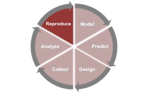

This is a reproduced and extended analysis from Rand, Arbesman, and Christakis (2011).

- Each player resides on a nonweighted network, with 20% possible links formed at *random*.
- His/her *neighbors* are players connected to him/her on this network.
- Each player exercises one of the following two actions during each round of the game.
  - Cooperation: paying 50 units for each neighbor and results in 100 units gain for each neighbor.
  - Defection: paying nothing and generating no benefits.
- Before each round, players are reminded of their number of neighbors and these neighbors’ prior decisions.
- After each round, players learn about the decisions of their neighbors and their own payoff.
- The probability for each subsequent round is 0.8, which was communicated to players.

Experimental conditions:

- **Fixed** links
- **Random** link updating (whole network regenerated at each round)
- Strategic link updating: a rewiring step following each round. Subject pairs are randomly selected and one randomly selected actor of the selected pair will be given the option to change the status between the pair (connected to disconnected, or disconnected to connected.) The deciding actor will be provided with behavior of the alter’s during the previous round. At the end of the rewiring step, each player will receive summaries about updates involved him/her.
  - **Viscous**: 10% randomly picked subject pairs selected to have an option of change.
  - **Fluid**: 30% randomly picked subject pairs selected to have an option of change.

### Download the data and import the data into `R`.

In the *notebook* mode, we are able to process data from a URL link. This greatly improves reproducibility.

```
[1] "sessionnum"         "condition"          "playerid"           "decision..0.D.1.C."
[5] "previous_decision"  "round_num"          "num_neighbors"      "group_size"
[9] "fluid_dummy"
```

|  | sessionnum | condition | playerid | decision..0.D.1.C. | previous_decision | round_num | num_neighbors | group_size | fluid_dummy |
| --- | --- | --- | --- | --- | --- | --- | --- | --- | --- |
| 265 | 1 | Static | 112 | 0 | 0 | 10 | 3 | 26 | 0 |
| 1829 | 18 | Viscous | 1804 | 1 | 1 | 5 | 6 | 15 | 0 |
| 1044 | 10 | Fluid | 1021 | 1 | 1 | 3 | 11 | 23 | 1 |
| 2999 | 35 | Static | 3517 | 0 | 0 | 3 | 4 | 21 | 0 |
| 1810 | 18 | Viscous | 1810 | 1 | 1 | 4 | 5 | 15 | 0 |
| 594 | 4 | Fluid | 432 | 1 |  | 1 | 9 | 32 | 1 |
| 3031 | 36 | Random | 3609 | 1 | 1 | 2 | 2 | 17 | 0 |
| 240 | 1 | Static | 133 | 0 | 0 | 9 | 7 | 26 | 0 |
| 3351 | 45 | Viscous | 4518 | 0 |  | 1 | 1 | 15 | 0 |
| 606 | 4 | Fluid | 403 | 1 |  | 1 | 9 | 32 | 1 |

[output cut: 40 more lines]

#### Basic information about the data set.

Here are some of the statistics for this data (generated in-line):

- There are 785 unique players
- In 40 sessions.
- Each session has one of the 4 conditions: Fixed, Random, Fluid, Viscous.

### Explore overall patterns of experimental sessions

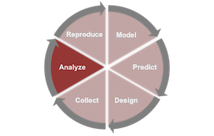

#### Here is the summarized session information.

|  | sessionnum | num_player | condition |
| --- | --- | --- | --- |
| 1 | 1 | 32 | Fixed |
| 2 | 7 | 22 | Fixed |
| 3 | 11 | 25 | Fixed |
| 4 | 16 | 11 | Fixed |
| 5 | 20 | 19 | Fixed |
| 6 | 24 | 10 | Fixed |
| 7 | 29 | 17 | Fixed |
| 8 | 35 | 21 | Fixed |
| 9 | 42 | 19 | Fixed |
| 10 | 48 | 14 | Fixed |

[output cut: 30 more lines]

#### The number of players vary within and between experimental conditions.

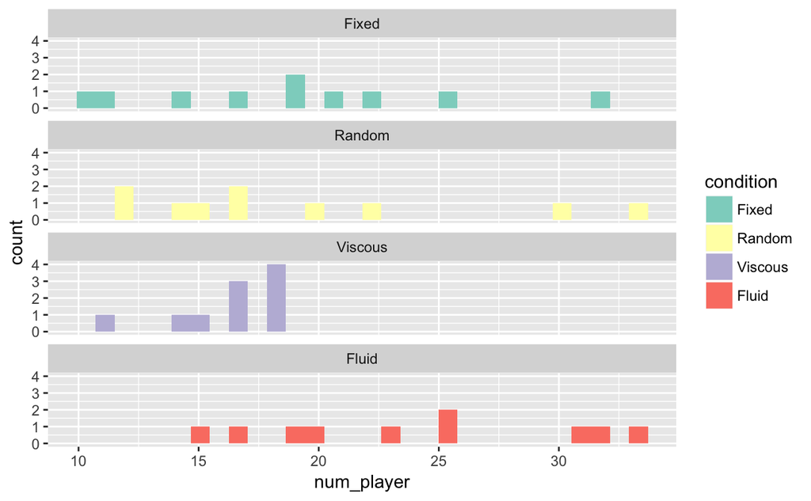

#### Cooperation rate over the course of a game.

- The rate of cooperation exhibits decline as the game proceeds
- The declining patterns are different between experimental conditions.

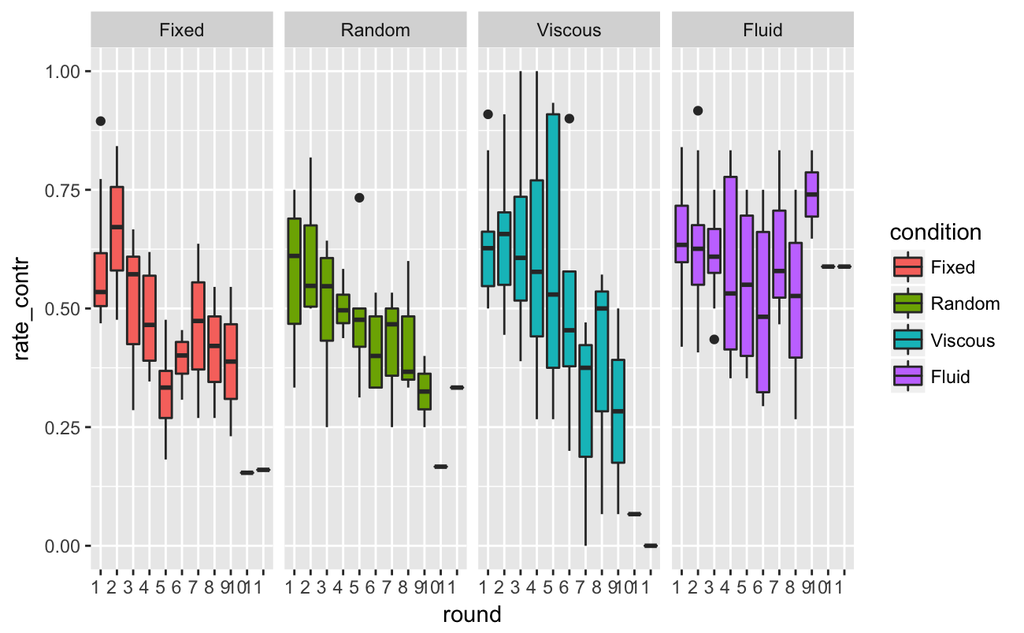

#### Behavior transition during the course of a game.

- Players most likely stay in one mode;
- And more likely to shift from cooperation to defection than vice versa.

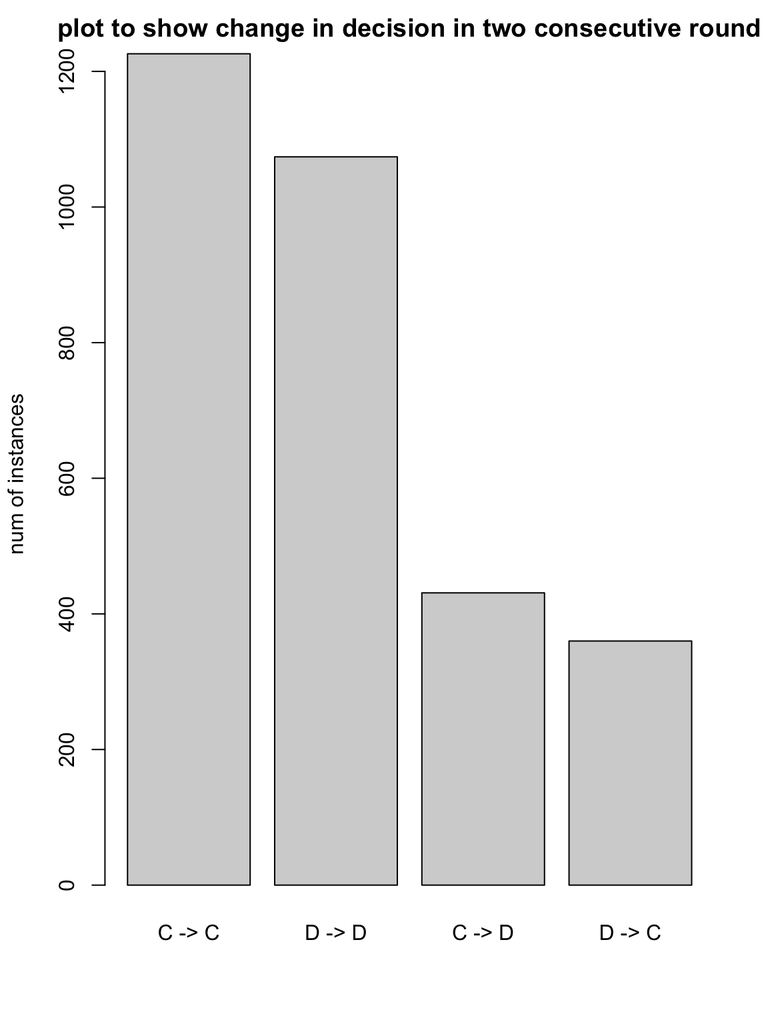

#### Association between behavior and social connections.

- Players’ tendence to contribute depends on their number of neighbors and whether they can choose their neighbors.

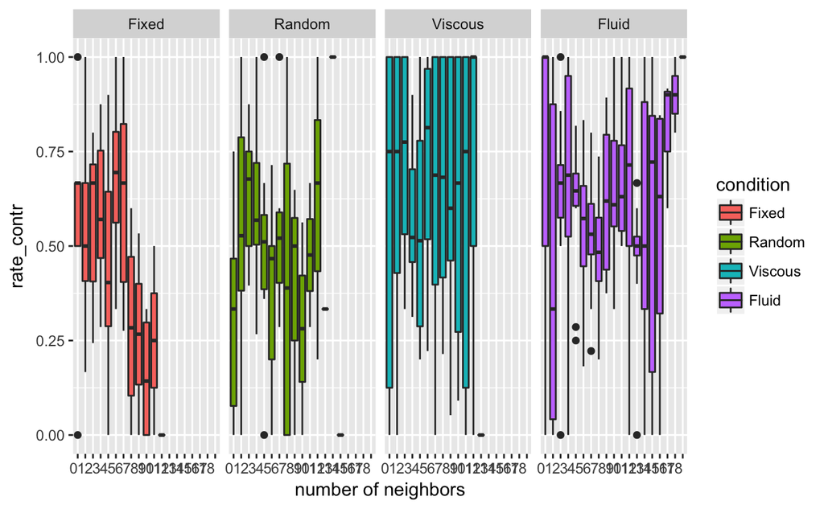

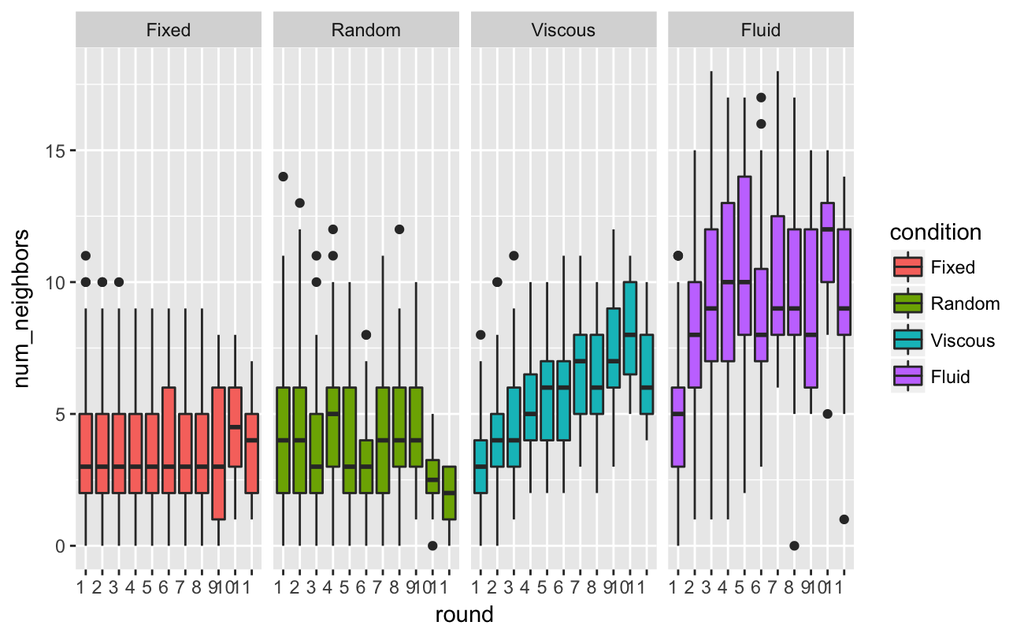

### Fitting logistic regression models.

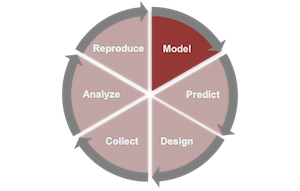

For the main model in Rand, Arbesman, and Christakis (2011), the factors of interest are *round number* and *fluid condition*.

Main conclusion from Rand, Arbesman, and Christakis (2011) states that *rapidly updating networks promote cooperation relative to other conditions* (coeff = 0.135, p = .006).

```
z test of coefficients:

                       Estimate Std. Error z value  Pr(>|z|)
(Intercept)            0.700215   0.122282  5.7263 1.027e-08 ***
fluid_dummy           -0.160946   0.230335 -0.6987  0.484709
round_num             -0.170558   0.030991 -5.5035 3.724e-08 ***
fluid_dummy:round_num  0.135445   0.049747  2.7227  0.006476 **
---
Signif. codes:  0 ‘***’ 0.001 ‘**’ 0.01 ‘*’ 0.05 ‘.’ 0.1 ‘ ’ 1
```

#### Logistic regression model under a Bayesian framework and carry out the modeling using Stan

##### Option 1, we can specify a full Bayesian logistic regression model from scratch.

```
data {

  int<lower=0> N; // Number of observations (an integer)
  int<lower=0> p; // Number of parameters
  // Variables
  int decision[N];
  int<lower=0>  round_num[N];
  int<lower=0>  fluid_dummy[N];
}

parameters {
  // Define parameters to estimate
  real beta[p];
}

transformed parameters  {
  // Probability trasformation from linear predictor
  real<lower=0> odds[N];
  real<lower=0, upper=1> prob[N];

  for (i in 1:N) {
    odds[i] = exp(beta[1] + beta[2]*fluid_dummy[i] + beta[3]*round_num[i] +   beta[4]*round_num[i]*fluid_dummy[i]);
    prob[i] = odds[i] / (odds[i] + 1);
  }
}

model {
  // Prior part of Bayesian inference (flat if unspecified)

  // Likelihood part of Bayesian inference
  decision ~ bernoulli(prob);
}
```

Convergence of the MCMC algorithm can be monitored and inspected.

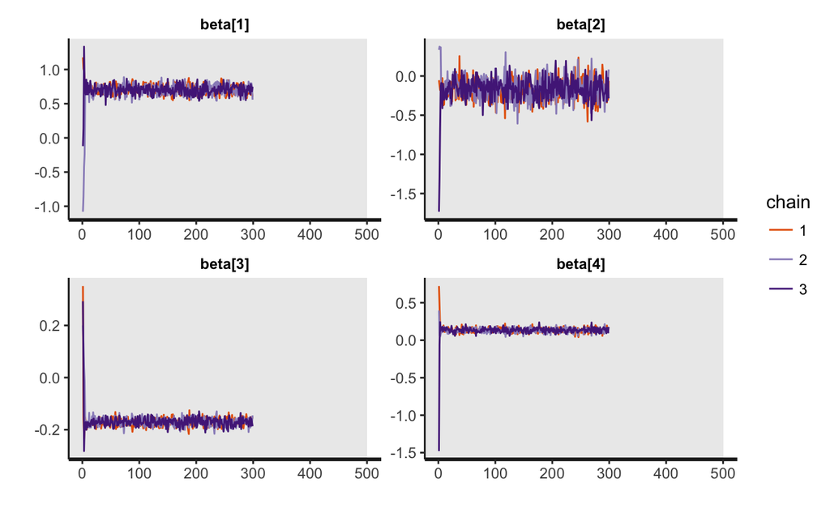

These are the coefficient in generalized linear model without stan:

```
          (Intercept)           fluid_dummy             round_num fluid_dummy:round_num
            0.7002150            -0.1609465            -0.1705581             0.1354445
```

These are the coefficients in generalized linear model when using Stan and our implementation of the model:

```
[1]  0.62537881 -0.02508902 -0.14735190  0.07989672
```

However, the mean of draws are:

```
[1]  0.7049809 -0.1634827 -0.1709487  0.1342733
```

##### Option 2, we can use wrapper functions provided in the `rstanarm` package.

```
                          Median     MAD_SD
(Intercept)            0.7009396 0.07187508
fluid_dummy           -0.1606585 0.13303671
round_num             -0.1705376 0.01507982
fluid_dummy:round_num  0.1354316 0.02906934
```

Posterior draws are:

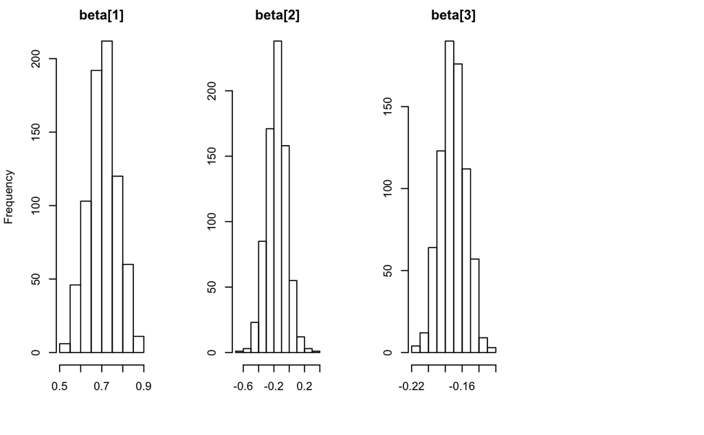

#### Predictive model checking

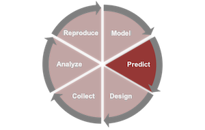

```
[1] 4500 3876
```

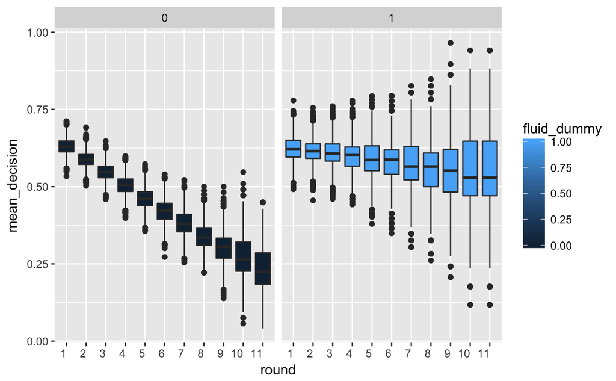

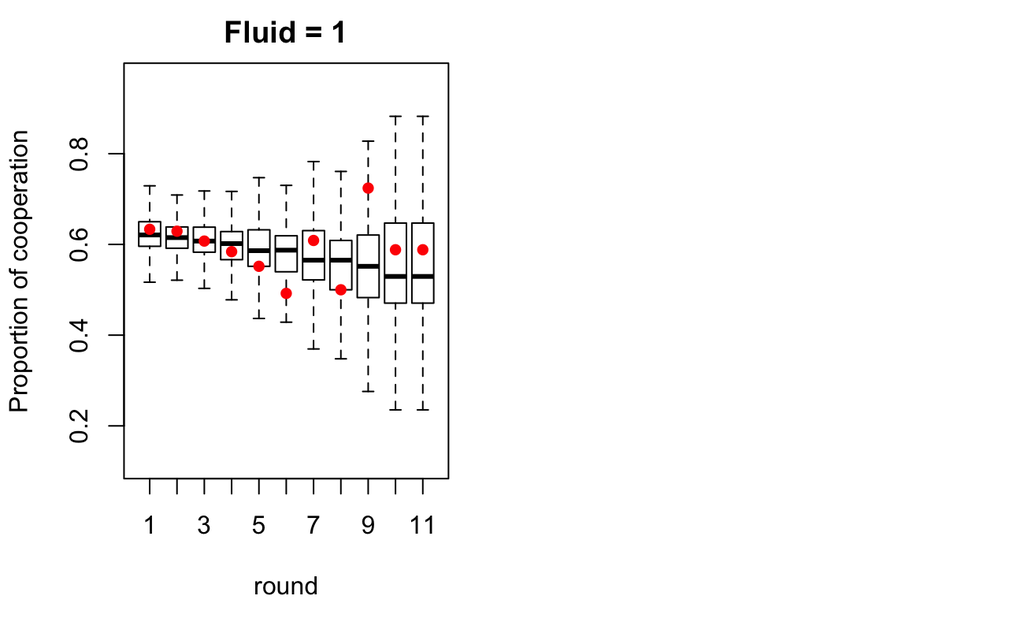

##### More detailed inspection of model fit for individual game sessions.

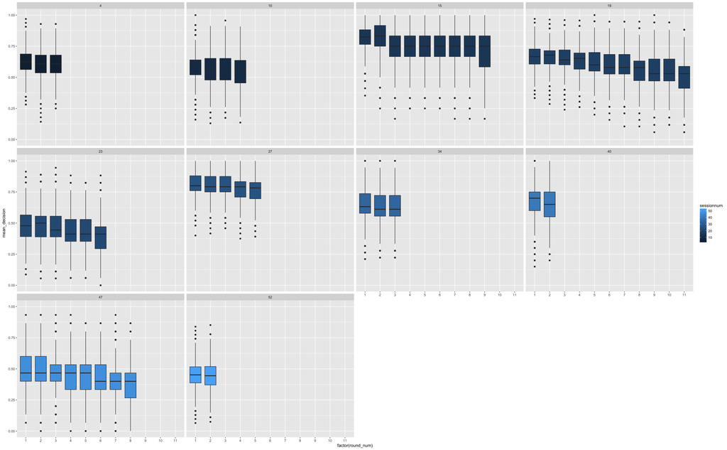

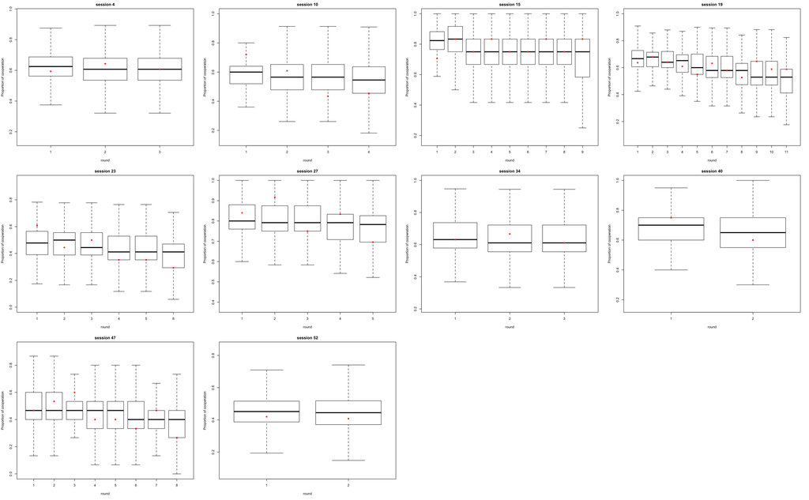

#### Extended logistic regression with random session effects.

```
[1] 4500 3876
```

##### Added session-level random effects lead to better fit.

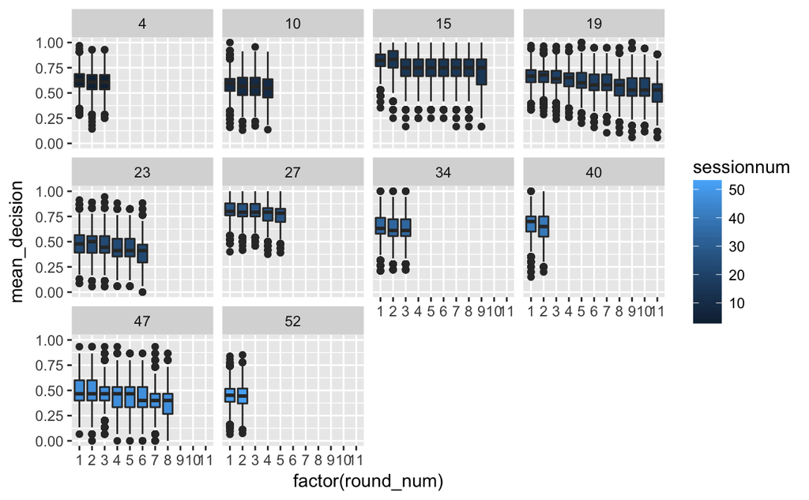

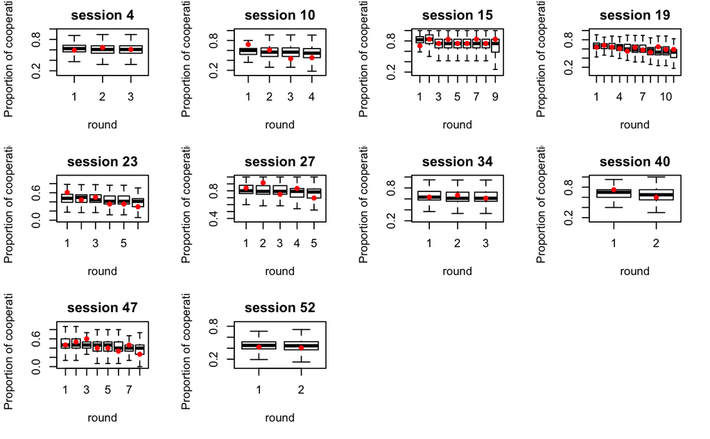

This report was produced in 8.568474 mins.

More examples of `rstanarm` can be found at https://cran.r-project.org/web/packages/rstanarm/.

Rand, David G., Samuel Arbesman, and Nicholas A. Christakis. 2011. “Dynamic Social Networks Promote Cooperation in Experiments with Humans.” *Proceedings of the National Academy of Sciences* 108 (48): 19193–8. doi:10.1073/pnas.1108243108.